# Introduction to spExtract package

Heather McDevitt

March 2020

This project is designed to install and introduce the package spExtract.

This file contains similar content as the package vignette titled “spExtract”. However, here we have installation code and we use real data from the Serengeti ecosystem in Tanzania to demonstrate the functions.

An R script containing the code used in this file is contained within the project, titled *“intro_code.R”*.

## Introduction

The package was created to bring together the necessary functions to extract NDVI values (including interpolating between scenes) at spatial locations.

These functions were originally written by Jon Lindsay and have since been adapted by Thomas Morrison and Heather McDevitt.

There are two additional helper functions included in this package:

4. `extract_matrix`
5. `extract_array`

These are designed to extract values from a matrix or an array which have been created from a Raster layer or Raster stack, respectively. These functions are used within `ndvi_extraction` to increase the speed of the function but they can also be used for independent extraction protocols, as with `raster::extract`.

*Note:* The speed improvement is trivial for small numbers of spatial location and for single raster layers but increases non-linearly so that `ndvi_extraction` is much quicker than if it used `raster::extract` internally. Examples of using `extract_matrix` and `extract_array` are included for clarity and completeness, but for most small tasks sticking to `raster::extract` will be more than sufficient, requiring fewer lines of code and less memory due to fewer objects being created.

## Installation and set-up

The package is stored on a GitHub repository here: https://github.com/hmcdevitt/spExtract

To install a package from GitHub you need to use the install_github() function in the devtools package.

```r
library(devtools)
install_github("hmcdevitt/spExtract", build_vignettes = TRUE)
# you need to specifiy to also install the vignettes when installing from github
library(spExtract)
```

Once the package has been installed, you can view the vignettes associated with the package by running:

```r
vignette(package = "spExtract")
```

More vignettes with different names will be added as the package is developed. To open a specific vignette within any package simply run:

```r
vignette("name-of-vignette", package = "name-of-package")
```

Additionally, to access the documentation for any function within the package the regular `?` cammand can be used. For example:

```r
?extract_matrix
```

## Extract from a single raster

```r
# load elevation raster
library(raster)
elevation <- raster::raster("data/DEM_Serengeti.tif")
```

For this example we are using a subset of location data for one wildebeest tracked in January to March 2018. These data are owned by Grant Hopcraft (Grant.Hopcraft@glasgow.ac.uk). Please do not use or share beyond this project without permission.

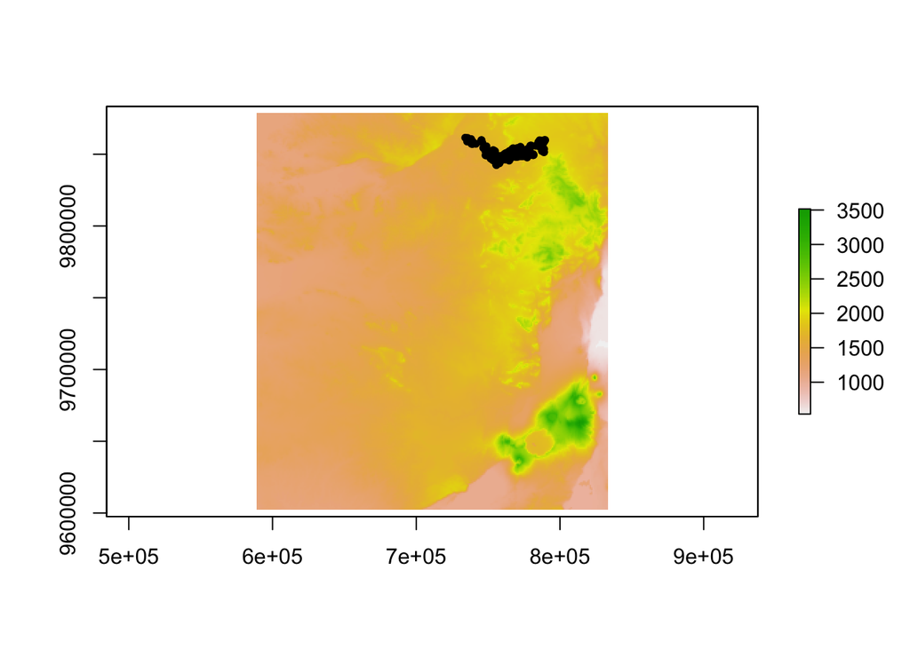

```r
# import location data
locations <- read.csv("data/locs.csv")

# turn into spatial object for plotting
library(sp)
loc_sp <- sp::SpatialPoints(coords = locations[,c("x","y")],
                        proj4string = raster::crs(elevation))

# plot point on elevation raster
plot(elevation)
plot(loc_sp, pch=20, add=T)
```

To use `extract_matrix` we need to convert the raster into a matrix and create objects of the raster extent and raster cell resolution. For more information see `?extract_matrix`.

```r
# create matrix
elev_mat <- raster::as.matrix(elevation)
# create extent object
elev_ext <- raster::extent(elevation)
# create cell resolution object
elev_res <- raster::res(elevation)
```

Now we can extract the values of elevation at the locations and add them to our dataframe.

```r
locations$elev <- spExtract::extract_matrix(matrix = elev_mat,
                                            coords = locations[,c("x","y")],
                                            raster_extent = elev_ext,
                                            raster_res = elev_res)

# view dataframe
head(locations, 10)
```

```
##    AID        x       y    OWNER           timestamp     elev
## 1  W68 734094.0 9861515 HOPCRAFT 2018-01-01 03:30:00 1626.728
## 2  W68 735752.1 9861363 HOPCRAFT 2018-01-01 07:31:00 1644.881
## 3  W68 735814.2 9859771 HOPCRAFT 2018-01-01 15:31:00 1610.994
## 4  W68 735398.1 9858859 HOPCRAFT 2018-01-01 23:30:00 1597.417
## 5  W68 735884.3 9859143 HOPCRAFT 2018-01-02 03:30:00 1597.417
## 6  W68 738181.6 9860598 HOPCRAFT 2018-01-02 07:30:00 1633.810
## 7  W68 738089.5 9858544 HOPCRAFT 2018-01-02 15:30:00 1624.069
## 8  W68 739284.7 9858016 HOPCRAFT 2018-01-02 23:30:00 1603.623
## 9  W68 738729.8 9857889 HOPCRAFT 2018-01-03 03:30:00 1617.353
## 10 W68 739011.8 9858801 HOPCRAFT 2018-01-03 07:30:00 1606.958
```

## Extract from an array

To be added.

## Extract NDVI

There are three stages to extract interpolated NDVI (iNDVI) values at given locations through time. The function also returns delta NDVI (dNDVI) and, optionally, anomaly NDVI (aNDVI). See `?ndvi_extraction` for more details on iNDVI, dNDVI and aNDVI.

```r
# Generate description of which files to compile into the NDVI array
files_desc <- spExtract::build_ndvi_desc(folder = "data/", # folder where NDVI tiffs are stored
                             start.date = "2018-01-01", # start date of data
                             end.date = "2018-03-31") # end date of data
```

```r
# Build array of NDVI layers for files identified in ndvi_files
ndvi_array <- suppressWarnings(spExtract::build_ndvi_array(files_desc = files_desc))
# note: the warning messages being suppressed here are not a problem and will be fixed inside the function soon
```

```r
# Import mean NDVI raster for aNDVI calculation
mean_raster <- raster("data/NDVI_mean_2000049-2019033.tif") # Folder path for mean NDVI rasters
mean_raster_utm <- projectRaster(from = mean_raster, crs = raster::crs(elevation)) # covert to same projection as everything else
ndvi_mean_matrix <- as.matrix(mean_raster_utm) # create as matrix
ndvi_extent <- extent(mean_raster_utm) # create raster extent object
ndvi_res <- res(mean_raster_utm) # create raster cell resolution object
```

```r
# Extract iNDVI, dNDVI and aNDVI at locations
ndvi_results <- spExtract::ndvi_extraction(files_desc = files_desc,
                                           array = ndvi_array,
                                           extent = ndvi_extent,
                                           resolution = ndvi_res,
                                           avg_matrix = ndvi_mean_matrix,
                                           date = as.Date(locations$timestamp),
                                           coords = locations[,c("x","y")])

# Add results to dataframe
locations <- cbind(locations, ndvi_results)

# View results
head(locations, 10)
```

```
##    AID        x       y    OWNER           timestamp     elev    indvi
## 1  W68 734094.0 9861515 HOPCRAFT 2018-01-01 03:30:00 1626.728 5.077902
## 2  W68 735752.1 9861363 HOPCRAFT 2018-01-01 07:31:00 1644.881 5.401196
## 3  W68 735814.2 9859771 HOPCRAFT 2018-01-01 15:31:00 1610.994 5.004939
## 4  W68 735398.1 9858859 HOPCRAFT 2018-01-01 23:30:00 1597.417 4.719966
## 5  W68 735884.3 9859143 HOPCRAFT 2018-01-02 03:30:00 1597.417 4.844943
## 6  W68 738181.6 9860598 HOPCRAFT 2018-01-02 07:30:00 1633.810 5.086095
## 7  W68 738089.5 9858544 HOPCRAFT 2018-01-02 15:30:00 1624.069 4.666147
## 8  W68 739284.7 9858016 HOPCRAFT 2018-01-02 23:30:00 1603.623 5.112513
## 9  W68 738729.8 9857889 HOPCRAFT 2018-01-03 03:30:00 1617.353 4.813634
## 10 W68 739011.8 9858801 HOPCRAFT 2018-01-03 07:30:00 1606.958 5.014878
##         dndvi        andvi
## 1  0.05834401  0.072156475
## 2  0.07002172  0.084458812
## 3  0.10910401  0.009602661
## 4  0.11275595 -0.049127196
## 5  0.08590692  0.010730124
## 6  0.09439099  0.059153057
## 7  0.07013676  0.028512151
## 8  0.05222508  0.050716797
## 9  0.05201924  0.062665263
## 10 0.05524400  0.078706483
```